# TreeSearch vs TNT: Benchmark Comparison

Author

TreeSearch Development

Published

March 20, 2026

## Overview

This report compares the phylogenetic search performance of **TreeSearch** (C++ driven search engine) against **TNT 1.6** (Goloboff & Catalano 2016) across a suite of morphological datasets.

Both programs implement “new technology” search strategies (Wagner tree + TBR + sectorial search + ratchet + drift + tree fusing). The comparison focuses on:

- **Score quality**: Does each engine find equally good trees?
- **Speed**: Wall-clock time to convergence.
- **Scaling**: How does performance change with dataset size?

### Scoring caveat

TreeSearch uses the Brazeau et al. (2019) three-pass algorithm for inapplicable characters, while TNT treats inapplicable tokens as a regular character state. For datasets with inapplicable data, the two programs optimise *different objective functions*, so absolute scores are not directly comparable. What is comparable is each program’s ability to find its own optimum efficiently.

```r
library(tidyverse)
library(knitr)
```

## Load results

```r
# Find the most recent results CSV
csv_files <- list.files(".", pattern = "^tnt_compare_.*\\.csv$",
                        full.names = TRUE)
if (length(csv_files) == 0) {
  stop("No results CSV found. Run bench_tnt_compare.R first.")
}
results_file <- sort(csv_files, decreasing = TRUE)[1]
results <- read.csv(results_file, stringsAsFactors = FALSE)
cat("Loaded", nrow(results), "rows from", basename(results_file), "\n")
```

```
Loaded 15 rows from tnt_compare_20260320_2025.csv
```

## Score comparison

For each dataset, we compare the best score found across all seeds.

```r
score_summary <- results |>
  group_by(dataset, n_taxa, n_chars, weighting) |>
  summarise(
    tnt_best = min(tnt_score, na.rm = TRUE),
    ts_best = min(ts_score, na.rm = TRUE),
    tnt_median = median(tnt_score, na.rm = TRUE),
    ts_median = median(ts_score, na.rm = TRUE),
    n_runs = n(),
    .groups = "drop"
  ) |>
  arrange(n_taxa)

kable(score_summary, digits = 2,
      caption = "Best and median scores per dataset and weighting scheme")
```

Best and median scores per dataset and weighting scheme

| dataset | n_taxa | n_chars | weighting | tnt_best | ts_best | tnt_median | ts_median | n_runs |
| --- | --- | --- | --- | --- | --- | --- | --- | --- |
| Vinther2008 | 23 | 57 | EW | 78 | 79 | 78 | 79 | 3 |
| Aria2015 | 35 | 50 | EW | 142 | 143 | 142 | 143 | 3 |
| Griswold1999 | 43 | 137 | EW | 394 | 407 | 394 | 408 | 3 |
| Agnarsson2004 | 62 | 242 | EW | 765 | 778 | 765 | 778 | 3 |
| Zhu2013 | 75 | 253 | EW | 624 | 653 | 624 | 654 | 3 |

## Timing comparison

```r
timing_summary <- results |>
  group_by(dataset, n_taxa, weighting, timeout_s) |>
  summarise(
    tnt_median_s = median(tnt_wall_s, na.rm = TRUE),
    ts_median_s = median(ts_wall_s, na.rm = TRUE),
    speedup = median(tnt_wall_s, na.rm = TRUE) /
      median(ts_wall_s, na.rm = TRUE),
    .groups = "drop"
  ) |>
  arrange(n_taxa)

kable(timing_summary, digits = 3,
      caption = "Median wall-clock time (seconds) and TNT/TreeSearch ratio")
```

Median wall-clock time (seconds) and TNT/TreeSearch ratio

| dataset | n_taxa | weighting | timeout_s | tnt_median_s | ts_median_s | speedup |
| --- | --- | --- | --- | --- | --- | --- |
| Vinther2008 | 23 | EW | 10 | 0.25 | 1.19 | 0.210 |
| Aria2015 | 35 | EW | 10 | 0.46 | 2.06 | 0.223 |
| Griswold1999 | 43 | EW | 10 | 0.89 | 6.59 | 0.135 |
| Agnarsson2004 | 62 | EW | 10 | 1.11 | 6.30 | 0.176 |
| Zhu2013 | 75 | EW | 10 | 4.63 | 10.06 | 0.460 |

### Timing by dataset size

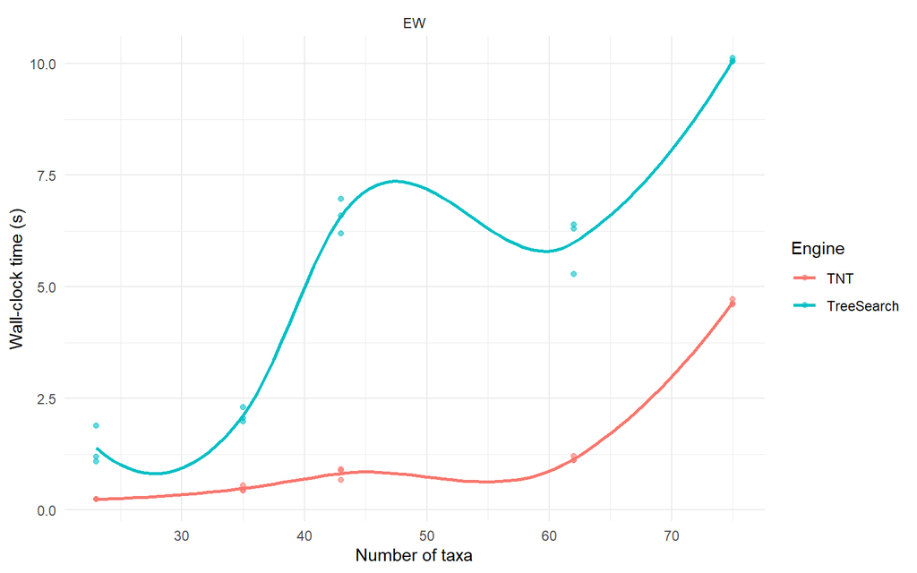

Figure 1: Wall-clock time vs number of taxa

```r
results_long <- results |>
  select(dataset, n_taxa, weighting, timeout_s, seed,
         tnt_wall_s, ts_wall_s) |>
  pivot_longer(cols = c(tnt_wall_s, ts_wall_s),
               names_to = "engine",
               values_to = "wall_s") |>
  mutate(engine = ifelse(engine == "tnt_wall_s", "TNT", "TreeSearch"))

ggplot(results_long, aes(n_taxa, wall_s, colour = engine)) +
  geom_point(alpha = 0.6) +
  geom_smooth(method = "loess", se = FALSE) +
  facet_wrap(~weighting) +
  labs(x = "Number of taxa", y = "Wall-clock time (s)",
       colour = "Engine") +
  theme_minimal()
```

## Score quality

How often does each engine find the best score (across both engines)?

```r
quality <- results |>
  group_by(dataset, weighting) |>
  mutate(
    overall_best = min(c(tnt_score, ts_score), na.rm = TRUE),
    tnt_optimal = tnt_score <= overall_best * 1.001,
    ts_optimal = ts_score <= overall_best * 1.001
  ) |>
  summarise(
    n_runs = n(),
    tnt_pct_optimal = round(100 * mean(tnt_optimal, na.rm = TRUE), 1),
    ts_pct_optimal = round(100 * mean(ts_optimal, na.rm = TRUE), 1),
    .groups = "drop"
  )

kable(quality,
      caption = "Percentage of runs finding the best-known score (within 0.1%)")
```

Percentage of runs finding the best-known score (within 0.1%)

| dataset | weighting | n_runs | tnt_pct_optimal | ts_pct_optimal |
| --- | --- | --- | --- | --- |
| Agnarsson2004 | EW | 3 | 100 | 0 |
| Aria2015 | EW | 3 | 100 | 0 |
| Griswold1999 | EW | 3 | 100 | 0 |
| Vinther2008 | EW | 3 | 100 | 0 |
| Zhu2013 | EW | 3 | 100 | 0 |

## Score vs taxa scatter

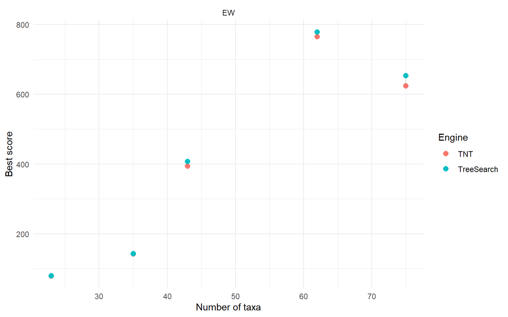

Figure 2: Best scores found by each engine per dataset

```r
score_long <- score_summary |>
  select(dataset, n_taxa, weighting, tnt_best, ts_best) |>
  pivot_longer(cols = c(tnt_best, ts_best),
               names_to = "engine", values_to = "best_score") |>
  mutate(engine = ifelse(engine == "tnt_best", "TNT", "TreeSearch"))

ggplot(score_long, aes(n_taxa, best_score, colour = engine)) +
  geom_point(size = 2.5) +
  geom_line(aes(group = interaction(dataset, weighting)), alpha = 0.3,
            colour = "grey50") +
  facet_wrap(~weighting, scales = "free_y") +
  labs(x = "Number of taxa", y = "Best score",
       colour = "Engine") +
  theme_minimal()
```

## Rearrangements (TNT)

TNT reports the total number of rearrangements examined, which gives a sense of search intensity.

```r
if ("tnt_rearrangements" %in% names(results)) {
  rearr <- results |>
    group_by(dataset, n_taxa, weighting, timeout_s) |>
    summarise(
      median_rearrangements = median(tnt_rearrangements, na.rm = TRUE),
      .groups = "drop"
    ) |>
    arrange(n_taxa)

  kable(rearr, digits = 0,
        caption = "Median TNT rearrangements per dataset")
}
```

Median TNT rearrangements per dataset

| dataset | n_taxa | weighting | timeout_s | median_rearrangements |
| --- | --- | --- | --- | --- |
| Vinther2008 | 23 | EW | 10 | 1460734 |
| Aria2015 | 35 | EW | 10 | 6988275 |
| Griswold1999 | 43 | EW | 10 | 13572561 |
| Agnarsson2004 | 62 | EW | 10 | 27258294 |
| Zhu2013 | 75 | EW | 10 | 119392306 |

## Raw results

```r
kable(results |> arrange(dataset, weighting, timeout_s, seed),
      digits = 3,
      caption = "Full results table")
```

Full results table

| dataset | n_taxa | n_chars | weighting | concavity | timeout_s | seed | tnt_score | tnt_n_trees | tnt_hits | tnt_rearrangements | tnt_wall_s | ts_score | ts_n_trees | ts_wall_s | ts_replicates | ts_hits |
| --- | --- | --- | --- | --- | --- | --- | --- | --- | --- | --- | --- | --- | --- | --- | --- | --- |
| Agnarsson2004 | 62 | 242 | EW | NA | 10 | 1 | 765 | 1 | 5 | 26638701 | 1.11 | 778 | 4 | 6.30 | 6 | 5 |
| Agnarsson2004 | 62 | 242 | EW | NA | 10 | 2 | 765 | 1 | 5 | 27258294 | 1.11 | 778 | 4 | 5.28 | 5 | 5 |
| Agnarsson2004 | 62 | 242 | EW | NA | 10 | 3 | 765 | 1 | 5 | 27710892 | 1.21 | 778 | 4 | 6.39 | 6 | 5 |
| Aria2015 | 35 | 50 | EW | NA | 10 | 1 | 142 | 64 | 5 | 7267091 | 0.56 | 143 | 40 | 2.31 | 20 | 2 |
| Aria2015 | 35 | 50 | EW | NA | 10 | 2 | 142 | 55 | 5 | 6988275 | 0.44 | 143 | 19 | 1.98 | 20 | 1 |
| Aria2015 | 35 | 50 | EW | NA | 10 | 3 | 142 | 56 | 5 | 6972661 | 0.46 | 144 | 27 | 2.06 | 20 | 1 |
| Griswold1999 | 43 | 137 | EW | NA | 10 | 1 | 394 | 11 | 5 | 14079947 | 0.91 | 408 | 8 | 6.20 | 20 | 2 |
| Griswold1999 | 43 | 137 | EW | NA | 10 | 2 | 394 | 14 | 5 | 13572561 | 0.89 | 408 | 14 | 6.97 | 20 | 2 |
| Griswold1999 | 43 | 137 | EW | NA | 10 | 3 | 394 | 15 | 5 | 13483118 | 0.67 | 407 | 1 | 6.59 | 20 | 1 |
| Vinther2008 | 23 | 57 | EW | NA | 10 | 1 | 78 | 20 | 5 | 1427137 | 0.25 | 79 | 51 | 1.19 | 8 | 5 |
| Vinther2008 | 23 | 57 | EW | NA | 10 | 2 | 78 | 20 | 5 | 1471900 | 0.25 | 79 | 51 | 1.09 | 7 | 5 |
| Vinther2008 | 23 | 57 | EW | NA | 10 | 3 | 78 | 13 | 5 | 1460734 | 0.24 | 79 | 52 | 1.89 | 17 | 5 |
| Zhu2013 | 75 | 253 | EW | NA | 10 | 1 | 624 | 27 | 5 | 118627255 | 4.61 | 653 | 1 | 10.04 | 7 | 1 |
| Zhu2013 | 75 | 253 | EW | NA | 10 | 2 | 624 | 26 | 5 | 119392306 | 4.72 | 658 | 1 | 10.06 | 8 | 1 |
| Zhu2013 | 75 | 253 | EW | NA | 10 | 3 | 624 | 32 | 5 | 119769483 | 4.63 | 654 | 1 | 10.12 | 8 | 1 |